# 2Hollis: Audio Feature Analysis

Author

Issei Crowley

## Who is 2Hollis

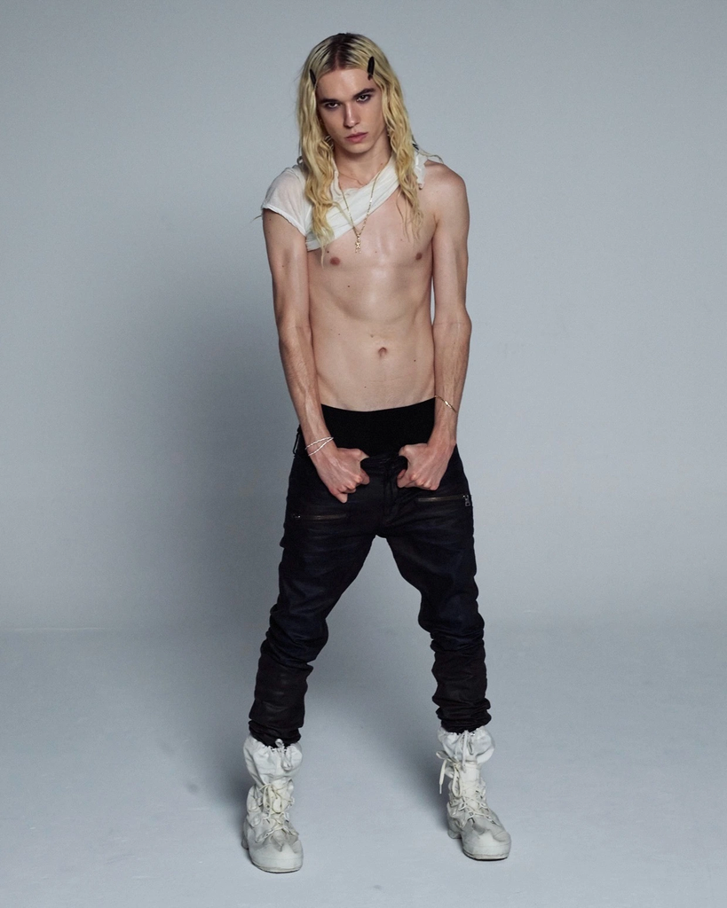

2hollis for his song style

2Hollis was born on the 5th of janurary, 2004. His real name is Hollus Parker Frazier-Herndon. His professional music carrer has only really started recently with his first full album in August of 2022, called White Tiger. He has released 3 other albums since then, one every year, with his latest releasing on April of 2025. He currently has 4.1 million monthly listeners on spotify.

### Fun fact!!!

His father is also a musician, John Herndon (also known as A Grape Dope) and he was/is the drummer of the band Tortoise

His mother is Kathryn Frazier, a prominent music industry figure who founded the PR firm Biz 3 and co-founded the record label Owsla.

There is a video of him in a car where his song jeans is playing on the radio and he is trying to open a water bottle but is very clearly struggling to open the bottle.

### My favorite song:

cliche, August 2023

[video not shown]

https://www.youtube.com/watch?v=SuCYsNERsgA&list=RDSuCYsNERsgA&start_radio=1

### Some other songs:

flash, July 2025

[video not shown]

https://www.youtube.com/watch?v=CjnFzPhM72I&list=RDCjnFzPhM72I&start_radio=1

jeans, October 2023

[video not shown]

https://www.youtube.com/watch?v=SuCYsNERsgA&list=RDSuCYsNERsgA&start_radio=1

### My favorite lyrics:

From the song “style” :

> “Seeing pennies on the street, I gotta pick up  
> Good luck, give me everything that I been needing”

> - 2Hollis

## Data Analysis

### Import data:

```r
#these are the packages I used  for the analysis
library(dplyr)
library(ggplot2)
library(readr)
```

```r
#importing data from the 3 latest albums into tables
Boy<-read.csv(("boy.csv"))
Star<-read.csv(("star.csv"))
Two<-read.csv(("2.csv"))
```

### Data preparation:

```r
#condensing the separate albums into 1 data source
Hollis<-rbind(Boy, Star, Two)
#this is just another way of condensing the 3 albums to a single source while keeping them separated by album
df_all <- bind_rows(
  Boy  %>% mutate(Album = "Boy"),
  Star %>% mutate(Album = "Star"),
  Two  %>% mutate(Album = "Two")
)
```

### Data frame:

This is just a sample of a few random songs from all the albums combined

```r
df_all|>dplyr::slice_sample(n=6) |>knitr::kable(digits = 2)
```

| Song | Acousticness | Danceability | Energy | Instrumentalness | Liveness | Loudness | Speechiness | Tempo | Valence | Album |
| --- | --- | --- | --- | --- | --- | --- | --- | --- | --- | --- |
| FORFEIT | 0.17 | 0.64 | 0.81 | 0.00 | 0.62 | -3.63 | 0.11 | 135.04 | 0.55 | Two |
| cope | 0.07 | 0.50 | 0.63 | 0.01 | 0.28 | -6.81 | 0.09 | 145.32 | 0.17 | Star |
| nothing2 lose | 0.10 | 0.70 | 0.64 | 0.00 | 0.60 | -7.30 | 0.34 | 129.98 | 0.62 | Two |
| tell me | 0.01 | 0.63 | 0.56 | 0.00 | 0.12 | -4.55 | 0.06 | 139.00 | 0.15 | Star |
| crush | 0.27 | 0.72 | 0.56 | 0.00 | 0.24 | -6.70 | 0.18 | 151.01 | 0.56 | Boy |
| flash | 0.03 | 0.54 | 0.77 | 0.00 | 0.56 | -3.90 | 0.12 | 136.08 | 0.27 | Star |

### Loudness vs Energy:

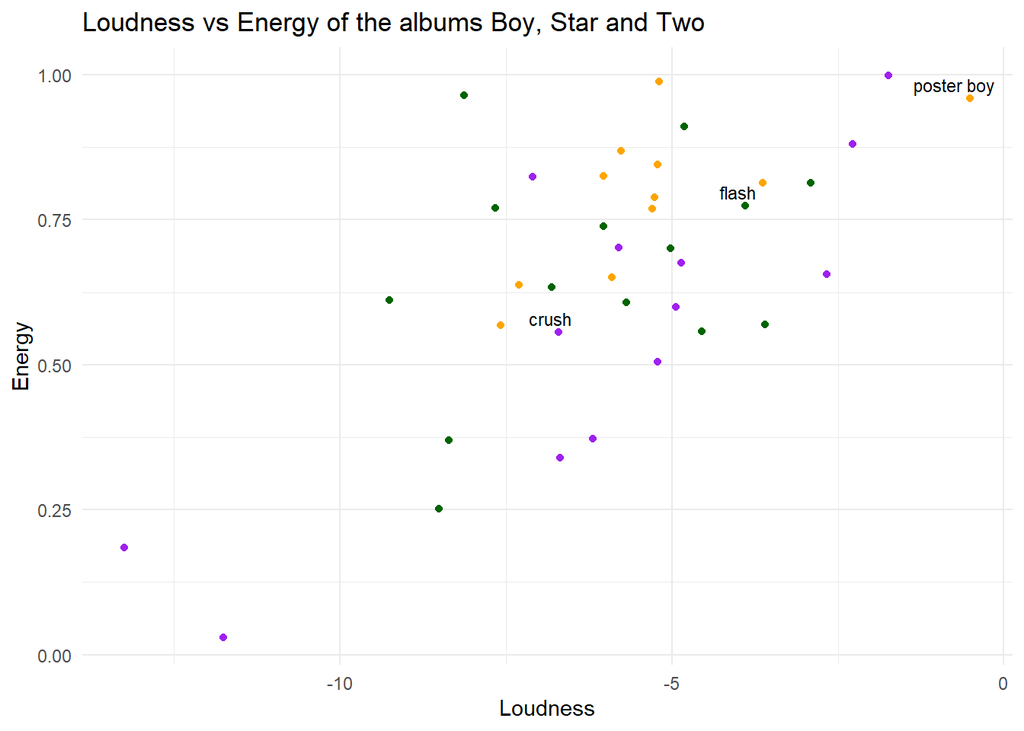

```r
df_all |>
  ggplot(aes(x = Loudness, y = Energy)) +
  geom_point(data = Boy, color = "purple", alpha = 1.0) +
  geom_point(data = Star, color = "darkgreen", alpha = 1.0) +
  geom_point(data = Two, color = "orange", alpha = 1.0) +
  geom_text(
  data = Hollis |> filter (Song %in% c("flash", "poster boy", "crush")),
  aes(label = Song),vjust = -0.5, hjust = 0.7, size = 3
  )+
   labs(
    title = "Loudness vs Energy of the albums Boy, Star and Two",
    x = "Loudness",
    y = "Energy") +
      theme_minimal()
```

### Tempo vs Danceability:

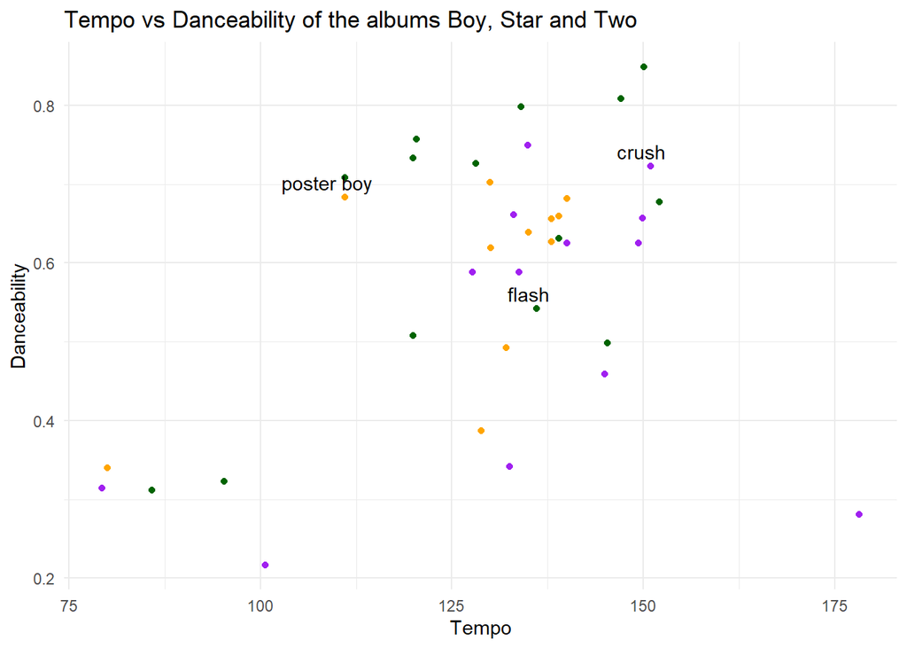

```r
 Hollis |>
  ggplot(aes(x = Tempo, y = Danceability)) +
  geom_point(data = Boy, color = "purple", alpha = 1.0) +
  geom_point(data = Star, color = "darkgreen", alpha = 1.0) +
  geom_point(data = Two, color = "orange", alpha = 1.0) +
  geom_text(
  data = Hollis |> filter (Song %in% c("flash", "poster boy", "crush")),
      aes (label = Song),
      vjust = -0.5, hjust = 0.7)+
 labs(
    title = "Tempo vs Danceability of the albums Boy, Star and Two",
    x = "Tempo",
    y = "Danceability"
  ) +
  theme_minimal()
```

### Acousticness between the 3 albums:

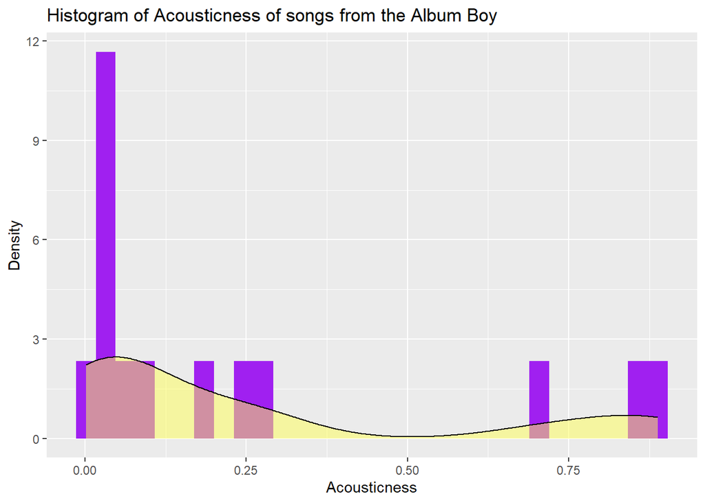

```r
 Boy|>
   ggplot(aes(x = Acousticness)) +
  geom_histogram(aes(y = after_stat(density)), fill = "purple") +
  geom_density(fill = "#FF5", alpha = 0.5) +
  labs(
    title = "Histogram of Acousticness of songs from the Album Boy",
    x = "Acousticness",
    y = "Density"
  )
```

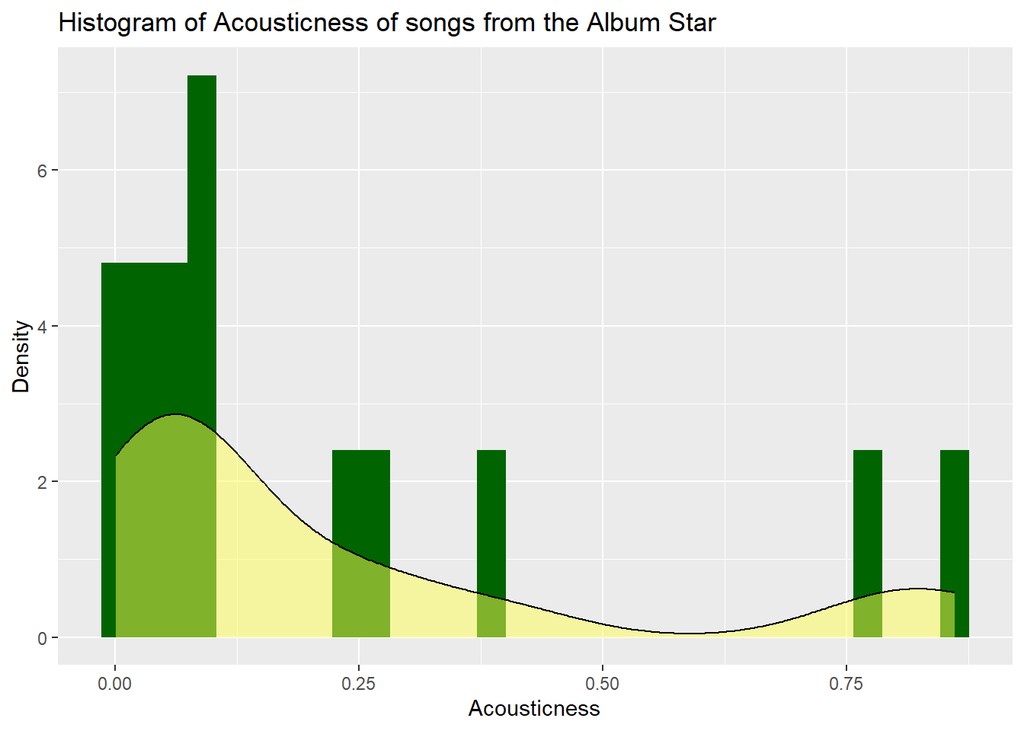

```r
 Star|>
   ggplot(aes(x = Acousticness)) +
  geom_histogram(aes(y = after_stat(density)), fill = "darkgreen") +
  geom_density(fill = "#FF5", alpha = 0.5) +
  labs(
    title = "Histogram of Acousticness of songs from the Album Star",
    x = "Acousticness",
    y = "Density"
  )
```

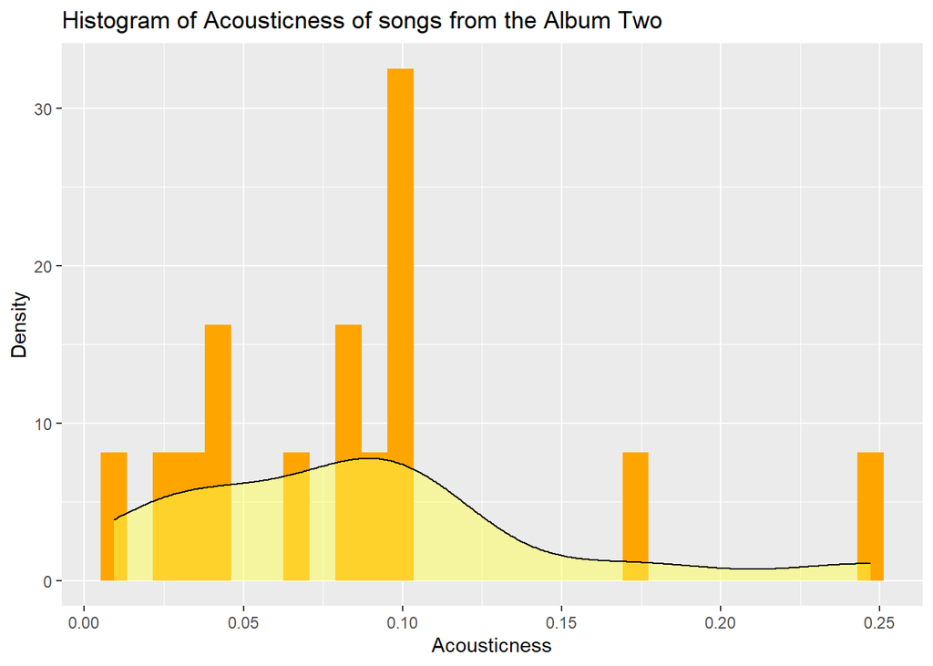

```r
 Two|>
   ggplot(aes(x = Acousticness)) +
  geom_histogram(aes(y = after_stat(density)), fill = "orange") +
  geom_density(fill = "#FF5", alpha = 0.5) +
  labs(
    title = "Histogram of Acousticness of songs from the Album Two",
    x = "Acousticness",
    y = "Density"
  )
```

### Tempo between the 3 albums

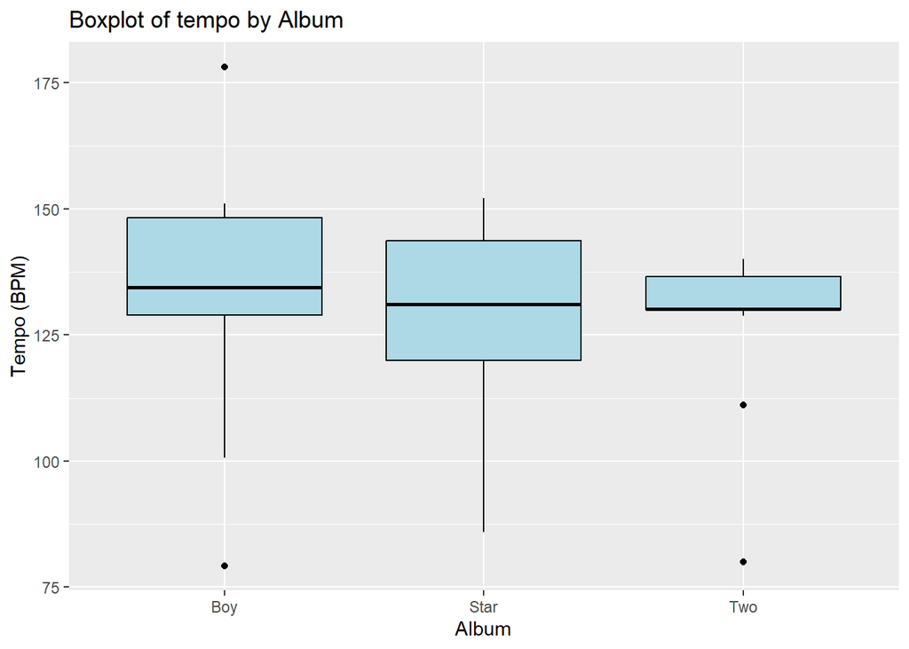

```r
ggplot(df_all, aes(x = Album, y = Tempo)) +
  geom_boxplot(fill = "lightblue", colour = "black") +
  labs(
    title = "Boxplot of tempo by Album",
    x = "Album",
    y = "Tempo (BPM)"
  )
```

### Valence vs Energy of the 3 abums:

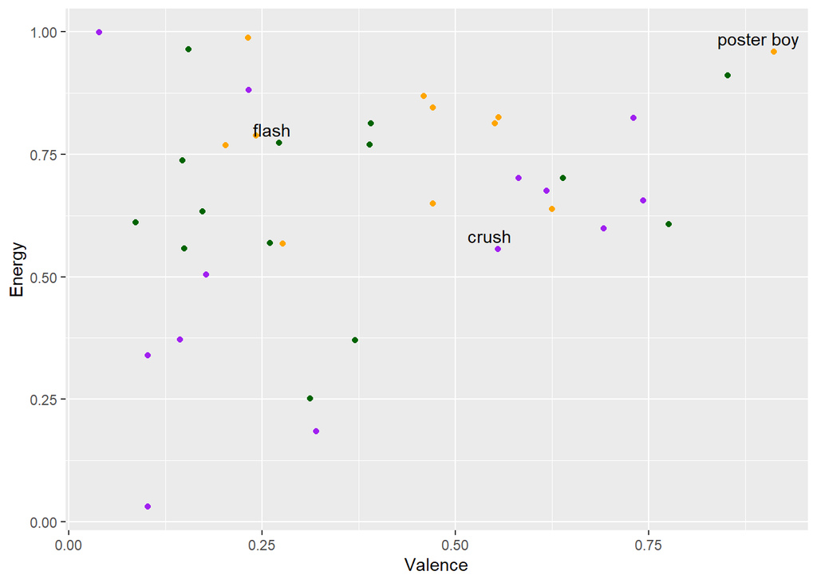

```r
Hollis |>
  ggplot(aes(x = Valence, y = Energy)) +
  geom_point(data = Boy, color = "purple", alpha = 1.0) +
  geom_point(data = Star, color = "darkgreen", alpha = 1.0) +
  geom_point(data = Two, color = "orange", alpha = 1.0) +
  geom_text(
  data = Hollis |> filter (Song %in% c("flash", "poster boy", "crush")),
      aes (label = Song),
      vjust = -0.5, hjust = 0.7
)
```

### Top 3 highest energy songs:

```r
df_all |> slice_max(Energy, n=3) |> dplyr::select(Song, Album, Energy) |> knitr::kable(digits = 2)
```

| Song | Album | Energy |
| --- | --- | --- |
| i saw it flash before me | Boy | 1.00 |
| fame runner | Two | 0.99 |
| beginning | Star | 0.96 |

### Top 3 lowest energy songs:

```r
df_all |> slice_min(Energy, n=3) |> dplyr::select(Song, Album, Energy) |> knitr::kable(digits = 2)
```

| Song | Album | Energy |
| --- | --- | --- |
| promise | Boy | 0.03 |
| say it | Boy | 0.18 |
| eldest child | Star | 0.25 |

Conclusion:

His growth as an artist is very quick, he went from a small artist to having his own tours within 2 years of releasing his first album. Most of his music is relatively high energy, tempo and are often have a relatively high danceability score.